# EDA Steve

```r
rm(list = ls())
```

## Importing data

```r
library(tidyverse)
library(tm)
twitter_data = read.csv("/Users/ssw107/Desktop/PhD/Wellcome Ideathon/EDA/The_Social_Scientists/data/vax_tweets.csv")
```

## Data types

```r
glimpse(twitter_data)
```

```
Rows: 100,000
Columns: 11
$ X                <int> 1, 2, 3, 4, 5, 6, 7, 8, 9, 10, 11, 12, 13, …
$ user_location    <chr> "Chicago", "Bengaluru, India", "", "", "not…
$ user_description <chr> "Official Twitter of Mercy Home for Boys & …
$ user_followers   <int> 4352, 40, 1915, 144, 184, 1539, 446, 223208…
$ user_friends     <chr> "2087", "0", "860", "329", "98", "1209", "4…
$ user_favourites  <chr> "1780", "0", "52127", "15876", "13359", "21…
$ user_verified    <chr> "TRUE", "FALSE", "FALSE", "FALSE", "FALSE",…
$ date             <chr> "12/03/2021 13:03", "10/03/2022 03:00", "19…
$ text             <chr> "We asked our coworkers why they're getting…
$ hashtags         <chr> "['FeelGoodFriday', 'MercyHomeCares', 'Covi…
$ is_retweet       <lgl> FALSE, FALSE, FALSE, FALSE, FALSE, FALSE, F…
```

### Replace blanks with NA

```r
twitter_data[twitter_data == ''] <- NA
```

### Proportion missing for each variable

```r
colMeans(is.na(twitter_data))
```

```
               X    user_location user_description   user_followers
         0.00000          0.21274          0.05507          0.00012
    user_friends  user_favourites    user_verified             date
         0.00012          0.00012          0.00012          0.00012
            text         hashtags       is_retweet
         0.00012          0.15468          0.00016
```

seems some tweets have no user_followers and just afew are retweets. 6% have no user description

### User with multiple fields missing

```r
twitter_data$na_count <- apply(twitter_data, 1, function(x) sum(is.na(x)))

missing = subset(twitter_data,twitter_data$na_count>=8)

View(missing)
twitter_data = subset(twitter_data,twitter_data$na_count<8)
```

### Removing users with no followers

```r
twitter_data = subset(twitter_data,!is.na(twitter_data$user_followers))
```

```r
summary(twitter_data$user_followers)
```

```
    Min.  1st Qu.   Median     Mean  3rd Qu.     Max.
       0      112      582    57428     2707 16583788
```

Can exclude users below 1st quartile? no justification, maybe leave them..need to discuss

### Remove duplicate tweets and other things

```r
# Removing Duplicate tweets
twitter_data$Duplicate = duplicated(twitter_data$text)
twitter_data = subset(twitter_data, twitter_data$Duplicate=="FALSE")
twitter_data$Duplicate=NULL

twitter_data$text = gsub("[[:digit:]]", "", twitter_data$text) #numbers

twitter_data$text=gsub("[^\x01-\x7F]", "", twitter_data$text) #non-ASCII characters

twitter_data$text = gsub("http\\w+", "", twitter_data$text) #links
```

### Removing troll tweets

#### Trolling Hashtags.

isolated several of the following hashtags that corresponded to the COVID-19 infodemic as defined by the WHO [83]. The specific hashtags that we identified included.

Source: https://arxiv.org/pdf/2012.02586.pdf

```r
remove.list <- paste(c(
  #People Died:
  "ChinaLiedPeopleDied", "WHOliedPeopleDied", "ChinaHideAndPeopleDied",
  #Sinophobic:
  "ChinaVirus","CCPvirus","ShameOnChina","#ChinesePlague","MakeChinaPay",
  #Iran:
  "liftsanctionsoniran","helpirancoronawhom",
  #Trump:
  "TrumpPandemic","TrumpVirus","TrumpLiesAboutCoronavirus",
  #Rumors:
  "DiseaseFree_With_TrueWorship","coronavirusstats",
  #Hoax:
  "CoronaVirusHoax","DemocraticHoax","CoronaVaccineHoax",
  #General Negativity :
  "waronhumanity","enemywithin",
  #Policy:
  "DefenseProductionActNow","BoycottChina",
  #Right-Leaning:
  "PelosiHatesAmericans","DemocraticHoax"

                       ), collapse = '|')

twitter_data = twitter_data %>% filter(!grepl(remove.list, hashtags))
```

#### Trolling Tropes

```r
remove.list <- paste(c("Russian scientist","war criminal","culpable","made in
China","genocide","torture","rape"
                       ), collapse = '|')

twitter_data = twitter_data %>% filter(!grepl(remove.list, text))

remove.list <- paste(c("eat","bats"
                       ), collapse = ' ')
twitter_data = twitter_data %>% filter(!grepl(remove.list, text))
```

### Major news events

#### Date format

```r
twitter_data$date_new = as.Date(substr(twitter_data$date, 1, 10), format="%d/%m/%Y")

twitter_data$date_time=as.POSIXlt(twitter_data$date,format="%d/%m/%Y %H:%M")

twitter_data$day <- day(twitter_data$date_time)
twitter_data$hour <- hour(twitter_data$date_time)
```

#### Tweets by date

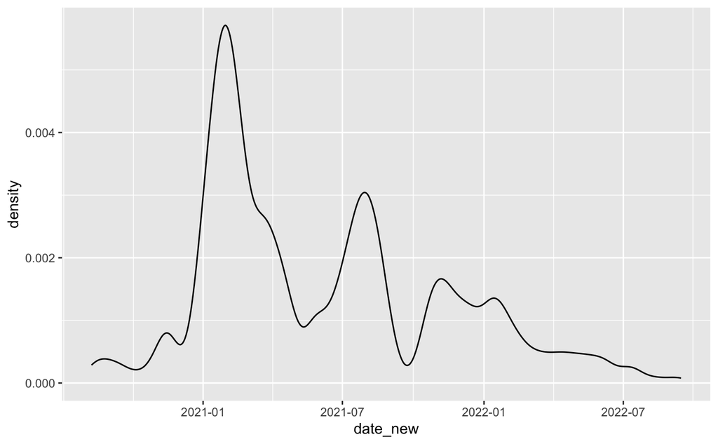

```r
ggplot(twitter_data, aes(x = date_new)) +
  geom_density()
```

More tweets between **January 2021 and March 2021** and again between **July 2021 and October 2021**

### UK timeline

https://www.instituteforgovernment.org.uk/sites/default/files/timeline-coronavirus-lockdown-december-2021.pdf

#### January 2021 and March 2021

- (2 Dec) Second lockdown ends after four weeks and England returns to a stricter three-tier system of restrictions
- (15 Dec) PM says Christmas rules will still be relaxed but urges the public to keep celebrations “short” and “small”
- (19 Dec) PM announces tougher restrictions for London and South East England, with a new Tier 4 ‘Stay at Home’ alert level.Christmas mixing rules tightened.
- (21 Dec) Tier 4 restrictions come into force in London and South East England
- (26 Dec) More areas of England enter Tier 4 restrictions
- (4 Jan) PM says PM says children should return to school after the Christmas break, but warns restrictions in England will get tougher.
- (6 Jan) England enters third national lockdown
- (15 Feb) Hotel quarantine for travellers arriving in England from 33 high-risk countries begins
- (22 Feb) PM publishes a roadmap for lifting the lockdown

#### July 2021 and October 2021

- (14 June) PM confirms that step 4 of the roadmap will be delayed by four weeks, until 19 July, as the government accelerates the vaccination programme.Restrictions on weddings and funerals abolished.
- (19 July) Most legal limits on social contact removed in England, and final closed sectors of the economy reopened (e.g.nightclubs).
- (14 Sep) PM unveils England’s winter plan for Covid – ‘Plan B’ to be used if the NHS is coming under “unsustainable pressure”,and includes measures such as face masks.

### US timeline

https://fraser.stlouisfed.org/timeline/covid-19-pandemic#140

#### January 2021 and March 2021

- December 11, 2020 | FDA Authorizes COVID-19 Vaccine
- December 18, 2020 | FDA Authorizes Second COVID-19 Vaccine
- December 23, 2020 | CDC Estimates COVID-19 Vaccinations Have Surpassed 1 Million First Doses in the United States
- December 27, 2020 | President Trump Signs the Coronavirus Response and Relief Supplemental Appropriations Act Into Law
- January 6, 2021 | CDC Estimates COVID-19 Vaccinations Have Surpassed 5 Million First Doses in the United States
- January 13, 2021 | CDC Estimates COVID-19 Vaccinations Have Surpassed 10 Million First Doses in the United States
- January 20, 2021 | President Biden Issues New COVID-19 Guidance
- January 28, 2021 | CDC Estimates COVID-19 Vaccinations Have Surpassed 25 Million in the United States
- January 29, 2021 | CDC Issues Public Transportation Mask Order
- February 13, 2021 | CDC Estimates COVID-19 Vaccinations Have Surpassed 50 Million in the United States
- February 27, 2021 | FDA Authorizes Third COVID-19 Vaccine
- March 2, 2021 | Texas Reopens and Lifts Mask Mandate
- March 2, 2021 | President Biden Invokes the Defense Production Act to Expedite Vaccine Production
- March 12, 2021 | CDC Estimates COVID-19 Vaccinations Have Surpassed 100 Million in the United States
- March 23, 2021 | Chair Powell and Treasury Secretary Yellen Give Testimony to Congress

#### July 2021 and October 2021

- June 22, 2021 | Chair Powell Gives Testimony to Congress
- June 23, 2021 | 600,000 COVID-19 Deaths in the United States
- July 27, 2021 | CDC Updates Guidelines for Fully Vaccinated People
- August 18, 2021 | CDC Announces Plans for COVID-19 Vaccine Booster Shots
- August 20, 2021 | Two Hundred Million People Have Received at Least One Vaccine Dose
- August 23, 2021 | FDA Approves First COVID-19 Vaccine
- September 22, 2021 | FDA Authorizes Booster Dose of COVID-19 Vaccine
- October 29, 2021 | FDA Authorizes COVID-19 Vaccine for Children 5 to 11 Years of Age

Tweets by day

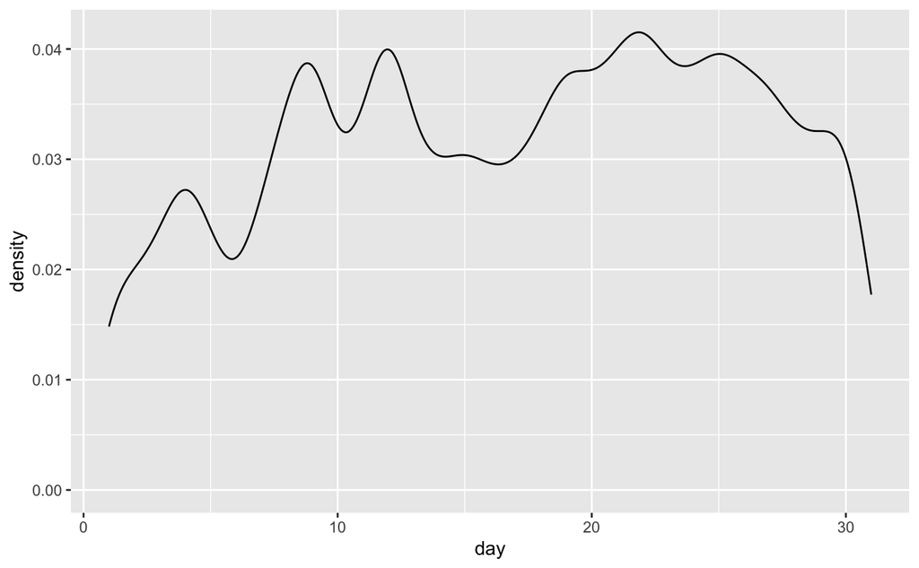

```r
ggplot(twitter_data, aes(x = day)) +
  geom_density()
```

Tweets by hour

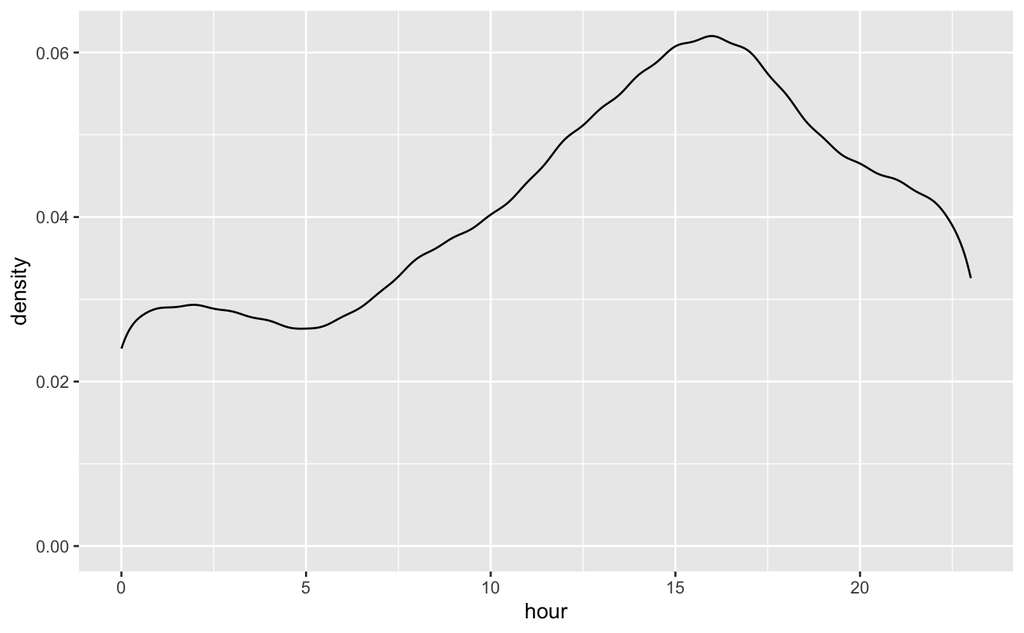

```r
ggplot(twitter_data, aes(x = hour)) +
  geom_density()
```

```r
write.csv(twitter_data,"/Users/ssw107/Desktop/PhD/Wellcome Ideathon/EDA/The_Social_Scientists/data/vax_tweets_cleanSW.csv",row.names = F)
```